# Coursework Report

| Group | *N* | *M*<sub>age</sub> | % green |
| --- | --- | --- | --- |
| Control | 66 | 20.7 | 32.8 |
| Experim | 70 | 20.7 | 52.9 |

| Gender | *N* | *M*<sub>age</sub> | % green |
| --- | --- | --- | --- |
| Male | 72 | 20.7 | 43.1 |
| Female | 41 | 20.6 | 44.7 |
| Other | 23 | 20.8 | 40.6 |

**Main analysis results**

**car:**  
χ<sup>2</sup>(1) = 0.34, *p* = .559

**cleaner:**  
χ<sup>2</sup>(1) = 12.3, *p* < .001

**dishwasher:**  
χ<sup>2</sup>(1) = 6, *p* = .014

# Coursework Report

Analysing Data, Spring 2020

# Methods

## Participants

The research took place at a large university in the south of England, and participants took part in the study in return for course credit. All participants arrived at the lab in small groups and were sat at computers separated by partitions. Five-hundred and four students took part in the study. However, nineteen participants’ results were removed for leaving ‘NA’ in place of their age and seventy-eight participants’ results were removed for entering an unreasonable age of under eighteen. This meant four-hundred and seven participants’ results were included in this report (215 male, 123 female, 69 identifying as ‘other’). (*M*<sub>age</sub> = 20.705, *SD*<sub>age</sub> = 1.884, *RANGE*<sub>age</sub> = 8).

The table below shows a summary of participant demographics by experimental condition

| Gender | condition | *N* | *M*<sub>age</sub> | *SD*<sub>Age</sub> |
| --- | --- | --- | --- | --- |
| male | control | 98 | 20.8 | 2.09 |
| male | experimental | 117 | 20.6 | 1.98 |
| female | control | 63 | 20.5 | 1.63 |
| female | experimental | 60 | 20.8 | 1.71 |
| other | control | 36 | 21.0 | 1.76 |
| other | experimental | 33 | 20.6 | 1.85 |

Figure 1 - Participant Demographics by Experimental Condition

## Design

The study examined how eliciting a status motive affected choices between luxurious ‘non-green’ products and less luxurious environmentally friendly ‘green’ products, predicting that eliciting such motives would increase the likelihood of choosing the less luxurious and more environmentally friendly ‘green’ products.

The study explores whether people in the high-status condition will choose the green products more often than people in the control condition. The statistical analysis that will be used to test whether results are significant is chi-squared.

# Results

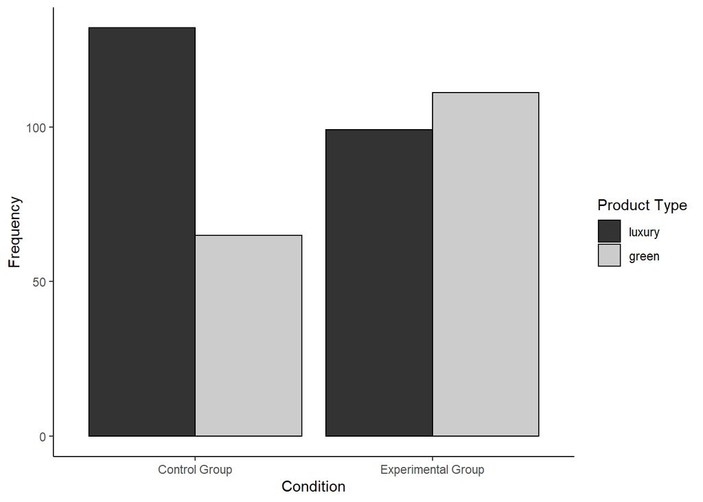

Figure 2 - Illustration of relationship between condition and product type chosen

The table below shows the results split into condition and product type chosen. The results show a higher number of participants opting for the luxurious products in the control condition, with a lower number opting for the non-luxurious green products. It also shows a higher number of participants opting for the non-luxurious green products in the experimental condition, with a lower number opting for the luxurious products.

```
##               product_type
## condition      luxury green
##   control         132    65
##   experimental     99   111
```

Figure 3 - Counts in each condition

The chi-squared statistical test produces the following results; there was a significant association between the condition and the product type chosen. *χ*<sup>2</sup>(1) = 15.54, *p* = 0. P < 0.05, which means the null hypothesis is unlikely to be true. We can therefore infer there is likely to be a relationship (accepting the alternative hypothesis) - high-status motives are likely to be related to how frequently people choose green products.

# Discussion

The results indicate that there is likely to be a relationship between high-status motives and how frequently people choose green products, with high status motives being likely to increase the frequency of green products chosen. This suggests ‘going green’ and choosing envrionmentally-friendly products may be at least partly due to status motives, rather than helping the planet itself.

The study produced similar results to the original study, which also found a significant association between the condition and product type chosen (F(1, 166) = 8.53, p = .004, d = 0.47.) (Griskevicius et al., 2010). With this study replicating the direction of results from the original study, the case for status motives having an effect on choosing envrionmentally-friendly products is further strengthened.

Studies on other similar areas also produce results in the same direction. One study found that men that involve themselves in conspicuous consumption (consumption of goods where self-presentational concerns override desires to obtain a bargain price) is triggered by short-term (as opposed to long-term) mating motives (Sundie et al., 2011). This study provides further evidence that consumerism is driven by status motives - in this case, wanting to have a short-term mating partner.

A possible explanation for why humans have such a fundamental concern for their status, with it even affecting the way they consume, is that status has an effect on health. A review study found that people’s subjective well-being, self-esteem and mental and physical health seem to depend on the level of status they are given by others. This was across different ages, genders, cultures and personalities, suggesting the status is something universal (Anderson et al., 2015). This further supports the study we carried out, as it highlights just how fundamental status is to humans, with it seeming to have the potential to have an effect on just about everything we do.

Based on the analysis and on the strengths and limitations of our study, alongside other pieces of research on the same area, it seems that the effect of status motives is a real phenomenon. High status really does seem to motivate people to buy green products. This is due to the fact our study near-replicated the results of the original green status motives study, along with the fact that participants in these studies indicated that they were not suspicious of the true aim of the study, so the results were highly unlikely to be due to demand characteristics. Additionally, as mentioned in the previous paragraph, there seems to be a clear underlying need for us to be concerned with status, with it having the potential to improve our mental and physical health.

It would be useful for researchers to next, instead of asking if status motives are linked to the products we choose, ask why these status motives seem to improve our mental and physical health. Researchers need to be questioning why they appear to be so fundamental to humans. Future studies could explore this question by trying to investigate a link between status motives and the quality and duration of relationships and careers. This is because if a link is found between these areas, it could explain why status motives improve our mental and physical health, with it being due to us having better and longer relationships and careers.

To conclude, status motives do appear to have an effect on the way we consume, such as whether we choose to buy environmentally friendly products. This is supported by our research and other existing papers. It would be useful to explore why there is a link between health and status.

# References

Anderson, C., Hildreth, J. A. D., & Howland, L. (2015). Is the desire for status a fundamental human motive? A review of the empirical literature. Psychological Bulletin, 141(3), 574–601. https://doi.org/10.1037/a0038781

Griskevicius, V., Tybur, J. M., & Van den Bergh, B. (2010). Going green to be seen: Status, reputation, and conspicuous conservation. Journal of Personality and Social Psychology, 98(3), 392–404. https://doi.org/10.1037/a0017346

Sundie, J. M., Kenrick, D. T., Griskevicius, V., Tybur, J. M., Vohs, K. D., & Beal, D. J. (2011). Peacocks, Porsches, and Thorstein Veblen: Conspicuous consumption as a sexual signaling system. Journal of Personality and Social Psychology, 100(4), 664–680. https://doi.org/10.1037/a0021669